# TA - Session 1 - VisualizingText

Visualization of text is an inportant discovery/explortion, that should be carried out to understand the structure/theme in the text. This helps us to expect the model to perform in tune with our understanding.

There are three approaches to feature exploration with texts. They are - tabular, graphical and wordcloud. Each approach has some merits and limitations. In this excercise we will explore the text from our earlier work on 'python.org' and a speech from present of USA (https://www.rev.com/blog/donald-trump-speech-transcript-turning-point-usa-teen-student-summit-speech).

```python
#Import libraries
import pandas as pd
import numpy as np
import matplotlib.pyplot as plt
from wordcloud import WordCloud
```

```python
#Creat some functions for cleaning and counting text
def wordfreq (words):
    """Function to generated the frequency distribution of the
given text"""
    word_freq={}
    for tok in words:
        if tok.lower() in word_freq:
            word_freq [tok.lower()]+=1
        else:
            word_freq [tok.lower()]=1
    return word_freq
def sort_tokens(tokens):
    import operator
    sorted_d = sorted(tokens.items(), key=operator.itemgetter(1),reverse=True)
    #print('Dictionary in descending order by value : ',sorted_d)
    #print(sorted_d[:25])
    return(sorted_d)
```

```python
text = "all your base are belong to us"
```

```python
wordcloud = WordCloud().generate(text)
```

[figure not shown]

```python
plt.imshow(wordcloud)
plt.axis("off")
plt.show()
```

```python
def plot_wordcloud(wordcloud):
    plt.imshow(wordcloud)
    plt.axis("off")
    plt.show()
```

[figure not shown]

[figure not shown]

```python
wordcloud = WordCloud().generate(text)
plot_wordcloud(wordcloud)
wordcloud = WordCloud(stopwords={'to', 'of'}).generate(text)
plot_wordcloud(wordcloud)
```

```python
#Explore couple of corpuses
import nltk
washington = nltk.corpus.inaugural.raw('1789-Washington.txt')
obama = nltk.corpus.inaugural.raw('2009-Obama.txt')
```

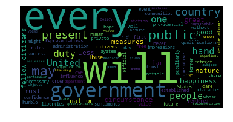

```python
wordcloud = WordCloud(relative_scaling=1.0).generate(washington)
plot_wordcloud(wordcloud)
```

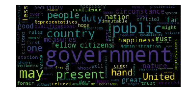

```python
from wordcloud import STOPWORDS

stopwords = set(STOPWORDS)
stopwords.add("every")
stopwords.add("will")
wordcloud = WordCloud(stopwords=stopwords, relative_scaling=1.0).generate(washington)
plot_wordcloud(wordcloud)
```

Now lets get on to understanding the utility of each of the tool for analysing the text. First lets explore the data from president's speech. The speech is available at: (https://www.rev.com/blog/donald-trump-speech-transcript-turning-point-usa-teen-student-summit-speech)

```python
#Trump speech
from urllib.request import urlopen
response = urlopen('https://www.rev.com/blog/donald-trump-speech-transcript-turning-point-usa-teen-student-summit-speech')
html = response.read()
print(len(html))
tokens = [tok for tok in html.split()]
```

```
187211
```

```python
#We clean it a bit
from bs4 import BeautifulSoup
print("Calling BS4")
soup = BeautifulSoup(html, 'html.parser')

# kill all script and style elements
for script in soup(["script", "style"]):
    script.extract()
```

```
Calling BS4
```

```python
tokens = [tok for tok in soup.get_text().split()]
```

```python
#Get the token
tokens = [tok for tok in soup.get_text().split()]
stop_words = ['>>>','and','to','the','for', 'is','of', '#','=','a','in','The', 'i', 'I', 'they', 'you', 'i', 'we', 'that', 'have','our', 'it', 'it’s','are','they','but','this', 'not', 'going', 'be', 'he', 'we’re', 'all', 'because']
tokens_clean = []
for token in tokens:
    if token in stop_words:
        pass
    else:
        tokens_clean.append(token)
#print(tokens_clean)
```

```python
print(tokens_clean[0:10])
```

```
['Donald', 'Trump', 'Speech', 'Transcript:', 'Turning', 'Point', 'USA', 'Teen', 'Student', 'Summit']
```

```python
new_tokens = wordfreq(tokens_clean)
```

```python
data = sort_tokens(new_tokens)
#print(data)
```

```python
#Sort the dcitionary on the basis of word freuqncy
import operator
sorted_d = sorted(new_tokens.items(), key=operator.itemgetter(1),reverse=True)
#print('Dictionary in descending order by value : ',sorted_d)
print(sorted_d[:25])
```

```
[('trump:', 141), ('they', 88), ('we', 84), ('was', 80), ('they’re', 61), ('don’t', 60), ('do', 60), ('will', 57), ('people', 57), ('that’s', 57), ('on', 55), ('so', 55), ('with', 54), ('what', 54), ('it.', 53), ('like', 52), ('and', 51), ('you', 51), ('just', 50), ('it’s', 49), ('one', 48), ('said,…
```

```python
#Create a Pandas dataframe for word frequency
import pandas as pd
word_frequency = pd.DataFrame(data, columns = ['word', 'frequency'])
```

```python
#Explore the word frequency
word_frequency.head(10)
```

|  | word | frequency |
| --- | --- | --- |
| 0 | trump: | 141 |
| 1 | they | 88 |
| 2 | we | 84 |
| 3 | was | 80 |
| 4 | they’re | 61 |
| 5 | don’t | 60 |
| 6 | do | 60 |
| 7 | will | 57 |
| 8 | people | 57 |
| 9 | that’s | 57 |

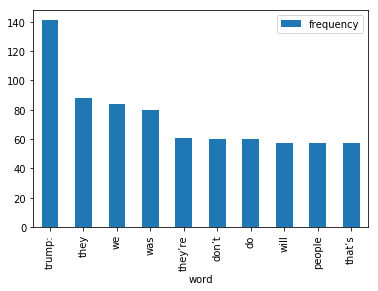

```python
#Plot word frequency of first few words as a bar plot
word_frequency[0:10].plot.bar('word', 'frequency')
```

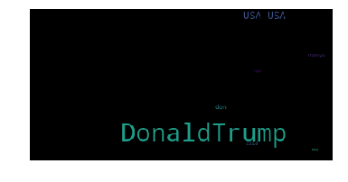

```python
#Now visualize the words with wordcloud
from wordcloud import STOPWORDS

stopwords = set(STOPWORDS)
stopwords.add("every")
stopwords.add("will")
wordcloud = WordCloud(stopwords=stopwords, relative_scaling=1.0).generate(''.join(tokens_clean))
plot_wordcloud(wordcloud)
```

This clearly shows, word cloud brings out 'Donald' and 'Trump' in its discovery profile. However, we were unable to see this combination clearly in word frequency. Lets plan another tour with the web site 'python.org'. This gives a different perspective altogether.

```python
#Clean text??
from urllib.request import urlopen
response = urlopen('http://python.org/')
html = response.read()
print(len(html))
tokens = [tok for tok in html.split()]
#print("Total no of tokens :"+ str(len(tokens)))
#print(tokens[0:100])
```

```
48781
```

```python
#We clean it a bit
from bs4 import BeautifulSoup
print("Calling BS4")
soup = BeautifulSoup(html, 'html.parser')
#print(soup.get_text())
# kill all script and style elements
for script in soup(["script", "style"]):
    script.extract()
#print(soup.get_text())
```

```
Calling BS4
```

```python
#Get the token
tokens = [tok for tok in soup.get_text().split()]
stop_words = ['>>>','and','to','the','for', 'is','of', '#','=','a','in','The', 'i', 'I', 'they', 'you', 'i', 'we', 'that', 'have','our', 'it', 'it’s','are','they','but','this', 'not', 'going', 'be', 'he', 'we’re', 'all', 'because']
tokens_clean = []
for token in tokens:
    if token in stop_words:
        pass
    else:
        tokens_clean.append(token)
#print(tokens_clean)
```

```python
print(tokens[0:100])
```

```
['Welcome', 'to', 'Python.org', 'Notice:', 'While', 'Javascript', 'is', 'not', 'essential', 'for', 'this', 'website,', 'your', 'interaction', 'with', 'the', 'content', 'will', 'be', 'limited.', 'Please', 'turn', 'Javascript', 'on', 'for', 'the', 'full', 'experience.', 'Skip', 'to', 'content', '▼', '…
```

```python
new_tokens = wordfreq(tokens)
```

```python
#Sort the dcitionary on the basis of word freuqncy
data = sort_tokens(new_tokens)
```

```python
#print('Dictionary in descending order by value : ',sorted_d)
print(data[:25])
```

```
[('python', 53), ('>>>', 24), ('and', 20), ('the', 18), ('to', 16), ('for', 14), ('more', 12), ('news', 11), ('events', 11), ('is', 10), ('community', 10), ('a', 10), ('of', 10), ('#', 9), ('with', 8), ('psf', 8), ('software', 8), ('=', 8), ('3', 8), ('in', 8), ('other', 7), ('your', 6), ('docs', 6)…
```

```python
#Create a Pandas dataframe for word frequency
word_frequency = pd.DataFrame(data, columns = ['word', 'frequency'])
```

```python
#Tabular data
word_frequency.head()
```

|  | word | frequency |
| --- | --- | --- |
| 0 | python | 53 |
| 1 | >>> | 24 |
| 2 | and | 20 |
| 3 | the | 18 |
| 4 | to | 16 |

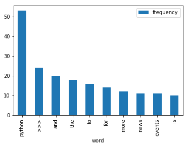

```python
#Word frequency as bar chart
word_frequency[0:10].plot.bar('word', 'frequency')
```

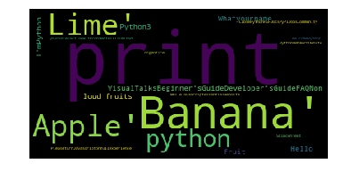

```python
#Now visualize the words with wordcloud
from wordcloud import STOPWORDS

stopwords = set(STOPWORDS)
stopwords.add("every")
stopwords.add("will")
wordcloud = WordCloud(stopwords=stopwords, relative_scaling=1.0).generate(''.join(tokens_clean))
plot_wordcloud(wordcloud)
```

```python
#Get cleaned tokens
#Get the token
tokens = [tok for tok in soup.get_text().split()]
stop_words = ['>>>','and','to','the','for', 'is','of', '#','=','a','in','The', 'i', 'I', 'they', 'you', 'i', 'we', 'that', 'have','our', 'it', 'it’s','are','they','but','this', 'not', 'going', 'be', 'he', 'we’re', 'all', 'because']
tokens_clean = []
for token in tokens:
    if token in stop_words:
        pass
    else:
        tokens_clean.append(token)
```

```python
new_tokens = wordfreq(tokens_clean)
data = sort_tokens(new_tokens)
print(data[:25])
```

```
[('python', 54), ('news', 11), ('events', 11), ('more', 11), ('community', 10), ('with', 9), ('psf', 8), ('software', 8), ('3', 8), ('docs', 6), ('other', 6), ('guide', 6), ('about', 5), ('code', 5), ('lists', 5), ('user', 5), ('group', 5), ('1', 5), ('product', 5), ('foundation', 5), ('your', 4), (…
```

```python
#Create a Pandas dataframe for word frequency
word_frequency = pd.DataFrame(data, columns = ['word', 'frequency'])
```

```python
#Tabular display of word frequency
word_frequency.head()
```

|  | word | frequency |
| --- | --- | --- |
| 0 | python | 54 |
| 1 | news | 11 |
| 2 | events | 11 |
| 3 | more | 11 |
| 4 | community | 10 |

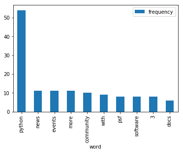

```python
#Word frequency as bar chart
word_frequency[0:10].plot.bar('word', 'frequency')
```

```python
print(tokens_clean[0:20])
```

```
['Welcome', 'Python.org', 'Notice:', 'While', 'Javascript', 'essential', 'website,', 'your', 'interaction', 'with', 'content', 'will', 'limited.', 'Please', 'turn', 'Javascript', 'on', 'full', 'experience.', 'Skip']
```

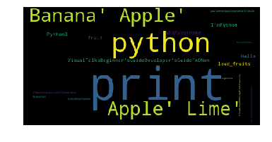

```python
#Visualize word frequency
wordcloud = WordCloud(stopwords=stopwords, relative_scaling=1.0).generate(''.join(tokens_clean))
plot_wordcloud(wordcloud)
```

In conclusion, there is no single visualization techniques which gives complete clarity on the conent. It is advisable use multiple approaches to explore/discover the themes/insights from text.